# Plasma Metabolite Alterations during SIV Infection

Kyle Kroll

2022-03-01

## Metabolomics of SIV

### Load Data

The data were generated by the Duke University MS Core. The data were delivered as quality controled excel files. Data were modified to follow typical tabular format for easy loading into R.

```r
ms.data <- read.delim("data/preprocessed.csv", sep = ",", check.names = F)
head(ms.data[, 1:10])
```

```
##   Sample Timepoint Group Sex  Age Treatment Infection     VL   C0    C2
## 1   M625       -21  IL21   F  674      None     Naive      0 25.1  4.83
## 2   M625         7  IL21   F  674      None       SIV   5369 33.7 12.90
## 3   M625        70  IL21   F  674      None       SIV  39039 28.4  6.78
## 4   M625        91  IL21   F  674      IL21       SIV  50530 35.0  9.68
## 5   DHAE       -21  IL21   M 1043      None     Naive      0 56.4 10.40
## 6   DHAE         7  IL21   M 1043      None       SIV 107360 26.9 15.70
```

We next need to format some of the columns so that their data types are correct. Namely converting the groups to a factor and the viral loads to a numeric.

```r
ms.data$Group <- factor(ms.data$Group, levels = c("Control", "IL15", "aIL15", "IL21"))
ms.data$VL <- as.numeric(ms.data$VL)
```

The final step of these initial analyses is to define the amino acids that we are interested in. For this analysis we will examine all 20 amino acids and their changes during acute and chronic SIV infection.

```r
amino.acids <- c("Ala", "Arg", "Asn", "Asp",
                 "Cys", "Glu", "Gln", "Gly",
                 "His", "Ile", "Leu", "Lys",
                 "Met", "Phe", "Pro", "Ser",
                 "Thr", "Trp", "Tyr", "Val")
```

Finally, we will load all the R libraries used for this analysis set.

```r
require(ggplot2)
require(dplyr)
require(rpart)
require(rpart.plot)
require(pheatmap)
require(caret)
```

### Heatmaps

The first analysis we will perform is a simple heatmap analysis to examine expression of the 20 amino acids during the three timepoints we are interested in: Pre-infection, Acute infection, and Chronic infection.

Since there is a sample that did not have Day -21 and Day 70 timepoints but did have Day 0 and Day 50, we will modify the timepoint labels to include that sample. We will first copy the raw data into a new data frame without the Day 91 timepoint since that is not of interest for this analysis.

```r
hm.data <- ms.data[, c("Sample", "Timepoint", amino.acids)]
hm.data <- hm.data %>% filter(Timepoint != 91)
hm.data$Timepoint <- ifelse(hm.data$Timepoint==70 | hm.data$Timepoint == 50, "Chronic",
                            ifelse(hm.data$Timepoint == 7, "Acute", "Pre"))
# Set the Timepoint as a factor and order the levels correctly
hm.data$Timepoint <- factor(hm.data$Timepoint, levels = c("Pre", "Acute", "Chronic"))
```

Next, we need to modify the `hm.data` data frame into a matrix format for the `pheatmap` function.

```r
# First let's make sure the timepoints are ordered correctly
hm.data <- with(hm.data, hm.data[order(Timepoint),])
# Next we need to transpose the data frame since pheatmap wants features in rows and samples in columns
hm.data <- as.data.frame(t(hm.data))
# Here we are using sapply to make sure all the columns are of a numeric class
mat <- as.matrix(sapply(hm.data[3:nrow(hm.data),], as.numeric))
# Set row name to the Amino Acid names
rownames(mat) <- rownames(hm.data)[3:22]
# convert our matrix to log2 for better visualization
mat <- log2(mat)
# Create annotation data frames that link the columns and rows to their correct identifiers
my_col <- as.data.frame(t(hm.data[2,,drop=F]))
# We also need to reset the factors for this
my_col$Timepoint <- factor(my_col$Timepoint, levels = c("Pre", "Acute", "Chronic"))
my_row <- as.data.frame(row.names(hm.data)[3:22])
```

Now that we have our data in the correct format we can simply pass these to the `pheatmap` function to visualize.

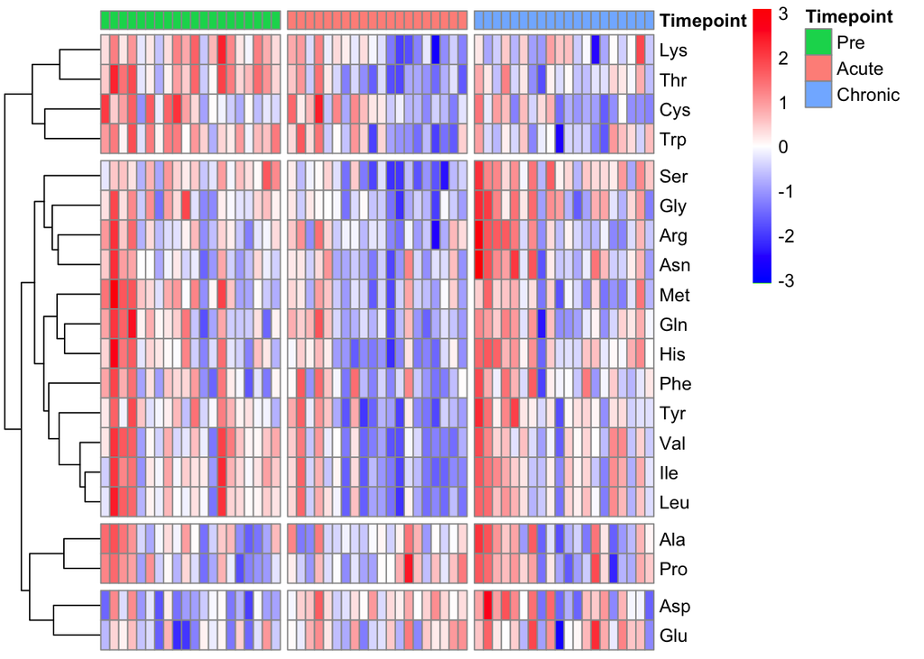

```r
# Creating a custom color ramp because I don't like the default one in pheatmap
colors <- c(min(mat),seq(-2,2,by=0.01),max(mat))
my_palette <- c("green",colorRampPalette(colors = c("blue", "white", "red"))
                (n = length(colors)-3), "red")
# We will cluster the rows because we are interested in clusters of amino acids potentially predicting viremia outcomes later on
# Gaps are used on both columns and rows for easier visualization of groups
pheatmap(mat,
         annotation_col = my_col,
         cluster_rows = T,
         cluster_cols = F,
         show_colnames = F,
         scale = "row",
         color = my_palette,
         gaps_col = c(20,40),
         cutree_rows = 4)
```

### Decision Tree

Our dataset is too small for statistically rigorous decision trees but as a proof-of-concept we will perform one anyway.

The first thing we need to do is create a new data frame of just the information we need. In order to do this we are going to take the Chronic timepoint and classify samples as either “Low” or “High” viremia based on if their viremia at chronic infection is less than or greater than the median, respectively.

```r
# Summarize data to obtain mean, media, standard deviation, and standard error
summ.ms.data <- ms.data %>%
  filter(Timepoint == 50 | Timepoint == 70) %>%
  summarize(avg = mean(VL), n = n(),
            std = sd(VL), se = std/sqrt(n),
            median = median(VL))
# Set Viral Load Group (VLG) based on median VL
vlg.labels <- ifelse(ms.data[ms.data$Timepoint==50 | ms.data$Timepoint == 70, "VL"] > summ.ms.data$median, "High", "Low")
names(vlg.labels) <- ms.data[ms.data$Timepoint==50 | ms.data$Timepoint == 70, "Sample"]

# Need to set all timepoints to use these grouping labels
for(x in unique(ms.data$Sample)) {
  ms.data[ms.data$Sample == x, "VLG"] <- vlg.labels[x]
}
ms.data <- ms.data[, c(1:8, 636, 9:635)]
for(x in colnames(ms.data)[10:636]) {
  ms.data[, x] <- as.numeric(ms.data[, x])
}
```

Next, we will make a new data frame for these analyses and split the data into a testing and training data frame. We are interested in examining pre-infection amino acid profiles to determine if there is a specific amino acid profile that can be predictive of lower viremia.

```r
# Take only the pre-infection timepoints since we are trying to find a predictive amino acid profile
data <- ms.data %>% filter(Timepoint == 0 | Timepoint == -21)
data <- data[, c("VLG", amino.acids)]
for(x in amino.acids) {
  data[, x] <- as.numeric(data[, x])
}
# Split the data into training and testing
set.seed(20220228)
set.seed(20220301)
inTrain = createDataPartition(data$VLG, p = .6)[[1]]
train = data[ inTrain,]
test = data[-inTrain,]
table(train$VLG)
```

```
##
## High  Low
##    6    6
```

```r
table(test$VLG)
```

```
##
## High  Low
##    4    4
```

Now, we can use `rpart` to generate a decision tree.

```r
model <- rpart(VLG~.,
               data = train,
               method="class",
               control=rpart.control(minsplit=2, minbucket=1, cp=0.001))
```

Now let’s plot the decision tree to see what, if any, are the predictive amino acid profiles.

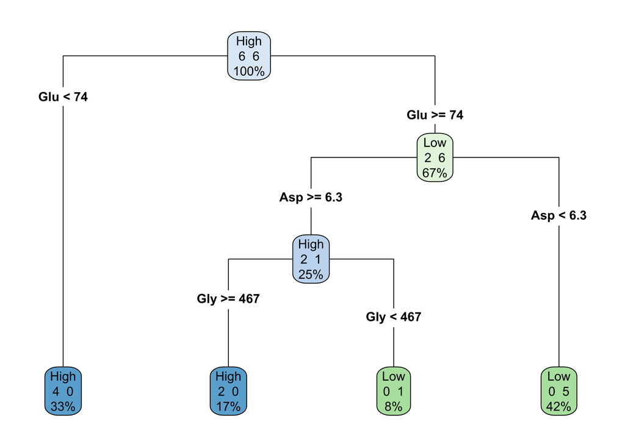

```r
rpart.plot(model, type = 4, extra = 101, tweak = 1, clip.right.labs = F)
```

```r
# Predict the test data set
pred <- predict(model, test, type = "class")
table(test$VLG, pred)
```

```
##       pred
##        High Low
##   High    3   1
##   Low     1   3
```

```r
# Examine the confusion matrix
confusionMatrix(table(pred, test$VLG))
```

```
## Confusion Matrix and Statistics
##
##
## pred   High Low
##   High    3   1
##   Low     1   3
##
##                Accuracy : 0.75
##                  95% CI : (0.3491, 0.9681)
##     No Information Rate : 0.5
##     P-Value [Acc > NIR] : 0.1445
##
##                   Kappa : 0.5
##
##  Mcnemar's Test P-Value : 1.0000
##
##             Sensitivity : 0.750
##             Specificity : 0.750
##          Pos Pred Value : 0.750
##          Neg Pred Value : 0.750
##              Prevalence : 0.500
##          Detection Rate : 0.375
##    Detection Prevalence : 0.500
##       Balanced Accuracy : 0.750
##
##        'Positive' Class : High
##
```

So we can see that with this small data set we achieve 75% accuracy. However, due to the small number of samples this may just be an over fitting problem and is not robust enough to predict real world outcomes.